# Pràctica 7 ANS

Lucas Poveda

2023-06-13

```r
library(mclust); library(FactoMineR); library(factoextra)
```

PRIMER EJERCICIO

# 1. Guarda la matriu en D. Posa noms a files i columnes. Guarda-ho com a dist`ancies (as.dist()).

```r
r1 <- c(0.00, 0.50, 0.43, 1.00, 0.25, 0.63, 0.38)
r2 <- c(0.50, 0.00, 0.71, 0.83, 0.67, 0.20, 0.78)
r3 <- c(0.43, 0.71, 0.00, 1.00, 0.43, 0.67, 0.33)
r4 <- c(1.00, 0.83, 1.00, 0.00, 1.00, 0.80, 0.86)
r5 <- c(0.25, 0.67, 0.43, 1.00, 0.00, 0.78, 0.38)
r6 <- c(0.63, 0.20, 0.67, 0.80, 0.78, 0.00, 0.75)
r7 <- c(0.38, 0.78, 0.33, 0.86, 0.38, 0.75, 0.00)
D <- rbind(r1,r2,r3,r4,r5,r6,r7)
rownames(D) <- LETTERS[1:7]
colnames(D) <- rownames(D)
D <- as.dist(D)
```

#2 Utilitza la funci´o hclust() de la llibreria mclust per obtenir els resultats per a diversos m`etodes: digues hc quan apliquis el metode complete, hs single, hw ward.D i hw2 ward.D2 :

```r
require(mclust)
hc <- hclust(D, method = "complete")
hs <- hclust(D, method = "single")
hw <- hclust(D, method = "ward.D")
hw2<- hclust(D, method = "ward.D2")
# ha <- hclust(as.dist(D), method = "average")
# hm<- hclust(as.dist(D), method = "median")
```

#3. Fes els dendrogrames de les 4 solucions amb plot(hc), etc. Prova-ho amb i sense l’opci´o hang=-1

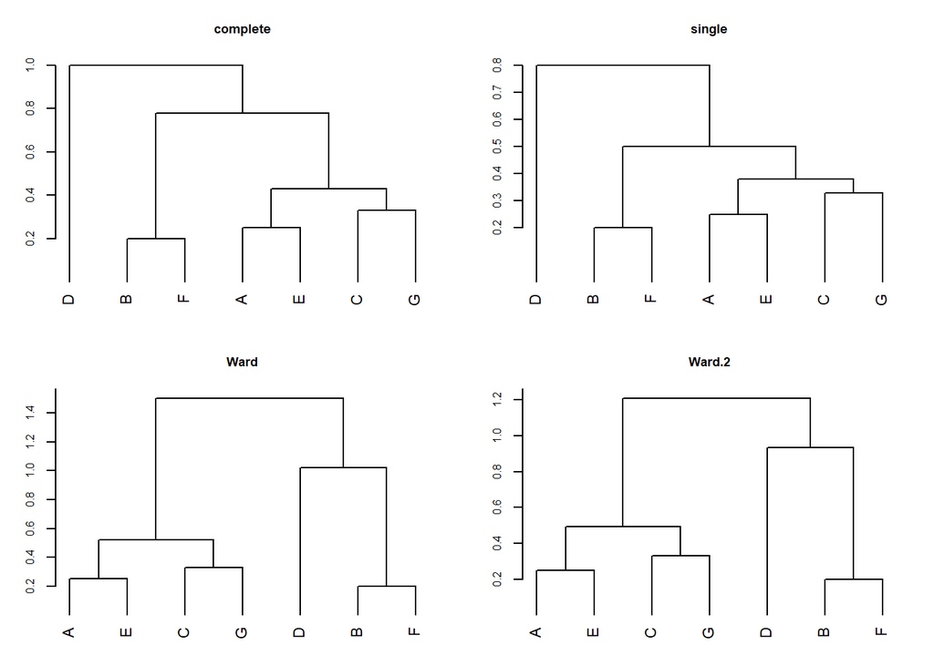

```r
par(mfrow=c(2,2), cex.axis=.7, cex.lab=.7, cex=.7, cex.main=.8, mar=c(1,3,3,2))
plot(hc, labels = row.names(D), ylab = "distance", main="complete", hang=-1)
plot(hs, labels = row.names(D), ylab = "distance", main="single", hang=-1)
plot(hw, labels = row.names(D), ylab = "Guany d'in`ercib between-clusters", main="Ward", hang=-1)
plot(hw2, labels = row.names(D), ylab = "Guany d'in`ercib between-clusters", main="Ward.2", hang=-1)
```

#4. Per a la soluci´o hc, mostra els objectes merge, height. Explica amb precisi´o quina informaci´o d´ona cadascun.

```r
hc$merge
```

```
##      [,1] [,2]
## [1,]   -2   -6
## [2,]   -1   -5
## [3,]   -3   -7
## [4,]    2    3
## [5,]    1    4
## [6,]   -4    5
```

```r
hc$height
```

```
## [1] 0.20 0.25 0.33 0.43 0.78 1.00
```

#6. Per a la soluci´o hc, aplica el criteri del “colze” en el diagrama de sedimentaci´o o scree graph de les altures o dist`ancies d’enlla¸c (height) per decidir el nombre de cl´usters k. Quin valor de k tries? Ajuda’t amb la visualitzaci´o del dendrograma i fixa’t com s’ha d’entendre l’ scree graph: comen¸ca per la dreta, si talles sota el primer punt ´es k = 2, sota del segon punt k = 3, etc. Cal tallar on el salt de les altures no sigui menyspreable, i sempre abans de sedimentar. Hi pot haver m´es d’una soluci´o que conv´e validar a posteriori (veure l’Exercici 2).

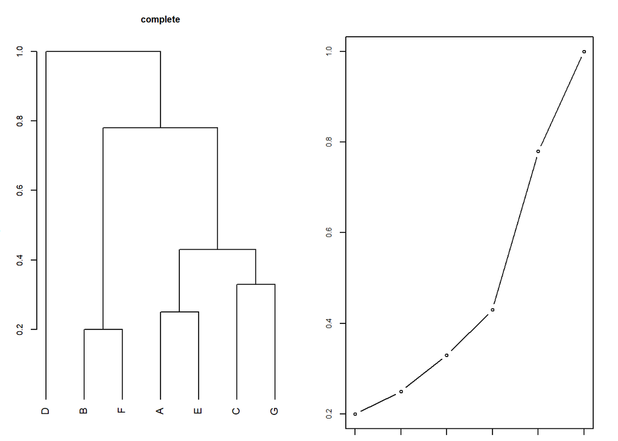

```r
par(mfrow=c(1,2), cex.axis=.8, cex.lab=.8, cex=.7, cex.main=.9, mar=c(1,3,3,2))
plot(hc, labels = row.names(D), ylab = "height", main="complete", hang=-1)
plot(hc$height, type="b",cex=.7, cex.lab=.7, cex.axis=.7)
```

```r
h <- hc$height
incr.h <- sort(h[-1]) - sort(h[-length(h)])
list(h=h,incr.h=incr.h)
```

```
## $h
## [1] 0.20 0.25 0.33 0.43 0.78 1.00
##
## $incr.h
## [1] 0.05 0.08 0.10 0.35 0.22
```

#7. Un cop decidit el nombre de cl´usters, aquests es poden enquadrar en el dendrograma amb la funci´o rect.hclust(). Aplica-la a hc amb k = 3 (has de tenir el dendrograma obert !). Esbrina qu`e fa la funci´o cutree(), i guarda el resultat en l’objecte clus

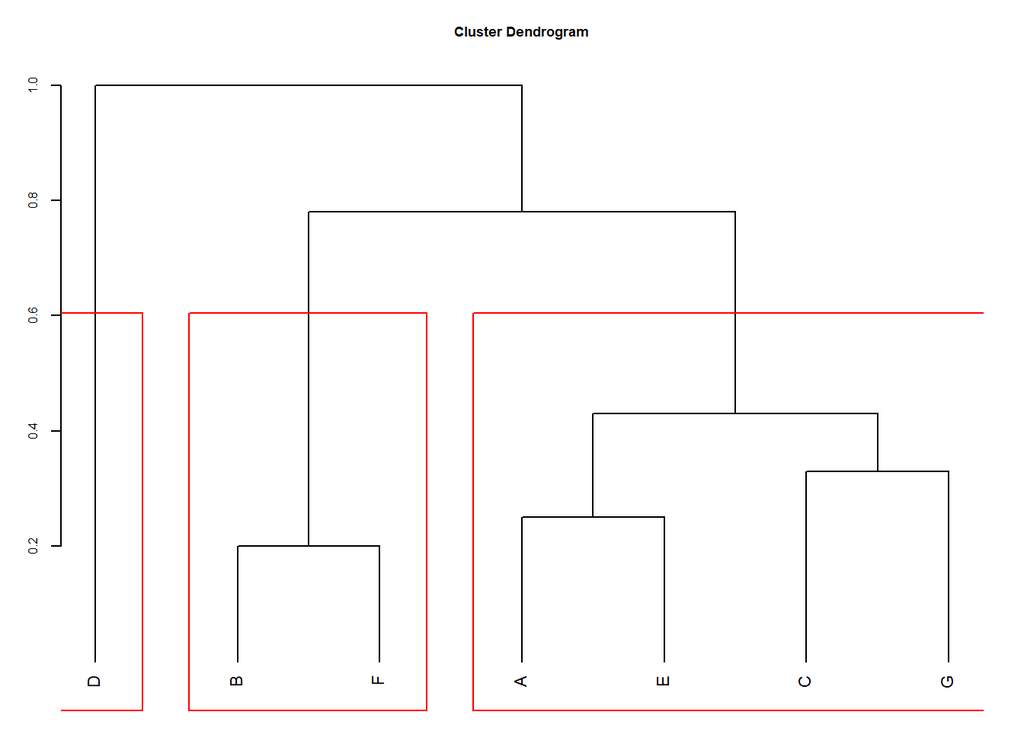

```r
par(mfrow=c(1,1), cex.axis=.7, cex.lab=.7, cex=.7, cex.main=.8, mar=c(1,3,3,2))
plot(hc, hang=-1)
k <- 3
rect.hclust(hc, k , border = "red")
```

```r
clus <- cutree(hc, k)
```

EJERCICIO 2

#1. Carrega el fitxer amb source() i guarda’l en lifeexp. Quina classe t´e aquest objecte? Quins elements t´e? Guarda en l’objecte life nom´es el primer element ($value). Com expliques que a Guatemala, per exemple, els valors de m0 i m25 fossin 49 i 40, respectivament? #2. Abreuja els noms de les files (pa¨ısos o regions), corregint manualment les abreujatures que creguis convenient.

```r
"life" <-
structure(.Data = list(c(63., 34., 38., 59., 56., 62., 50., 65., 56., 69., 65., 64., 56., 60., 61., 49., 59., 63., 59., 65., 65., 64.,
    64., 67., 61., 68., 67., 65., 59., 58., 57.)
, c(51., 29., 30., 42., 38., 44., 39., 44., 46., 47., 48., 50., 44., 44., 45., 40., 42., 44., 44., 48., 48., 63.,
    43., 45., 40., 46., 45., 46., 43., 44., 46.)
, c(30., 13., 17., 20., 18., 24., 20., 22., 24., 24., 26., 28., 25., 22., 22., 22., 22., 23., 24., 28., 26., 21.,
    21., 23., 21., 23., 23., 24., 23., 24., 28.)
, c(13., 5., 7., 6., 7., 7., 7., 7., 11., 8., 9., 11., 10., 6., 8., 9., 6., 8., 8., 14., 9., 7., 6., 8., 10., 8.,
    8., 9., 10., 9., 9.)
, c(67., 38., 38., 64., 62., 69., 55., 72., 63., 75., 68., 66., 61., 65., 65., 51., 61., 67., 63., 68., 67., 68.,
    68., 74., 67., 75., 74., 71., 66., 62., 60.)
, c(54., 32., 34., 46., 46., 50., 43., 50., 54., 53., 50., 51., 48., 45., 49., 41., 43., 48., 46., 51., 49., 47.,
    47., 51., 46., 52., 51., 51., 49., 47., 49.)
, c(34., 17., 20., 25., 25., 28., 23., 27., 33., 29., 27., 29., 27., 25., 27., 23., 22., 26., 25., 29., 27., 25.,
    24., 28., 25., 29., 28., 28., 27., 25., 28.)
, c(15., 6., 7., 8., 10., 14., 8., 9., 19., 10., 10., 11., 12., 9., 10., 8., 7., 9., 8., 13., 10., 9., 8., 10., 11.,
    10., 10., 10., 12., 10., 11.)
)
, class = "data.frame"
, names = c("m0", "m25", "m50", "m75", "w0", "w25", "w50", "w75")
, row.names = c("Algeria", "Cameroon", "Madagascar", "Mauritius", "Reunion", "Seychelles", "South Africa(C)", "South Africa(W)",
    "Tunisia", "Canada", "Costa Rica", "Dominican Rep", "El Salvador", "Greenland", "Grenada", "Guatemala",
    "Honduras", "Jamaica", "Mexico", "Nicaragua", "Panama", "Trinidad(62)", "Trinidad (67)",
    "United States (66)", "United States (NW66)", "United States (W66)", "United States (67)", "Argentina",
    "Chile", "Columbia", "Ecuador")
)
```

```r
rownames(life)<-abbreviate(rownames(life))
rownames(life)<-c(rownames(life)[1:6],"SAc","SAw",rownames(life)[9:21], "T62","T67","US66","USnw66","USw66", "US67",rownames(life)[28:31])
head(life)
```

```
##      m0 m25 m50 m75 w0 w25 w50 w75
## Algr 63  51  30  13 67  54  34  15
## Cmrn 34  29  13   5 38  32  17   6
## Mdgs 38  30  17   7 38  34  20   7
## Mrts 59  42  20   6 64  46  25   8
## Renn 56  38  18   7 62  46  25  10
## Sych 62  44  24   7 69  50  28  14
```

#3. Calcula la matriu de dist`ancies (Euclidianes) dels pa¨ısos (pots usar la funci´o dist()). #4. Aplica hclust() amb enlla¸c: simple, complet, ward.D i ward.D2. i guarda’ls en hs, hc, hw, hw2, respectivament. Dibuixa els dendrogrames en una figura 2 × 2 (fes que totes les branques s’ajustin a l’eix horitzontal).

```r
D<-dist(life)
hs <- hclust(D, method = "single")
hc <- hclust(D, method = "complete")
hw <- hclust(D, method = "ward.D")
hw2<- hclust(D, method = "ward.D2")
```

#5. Pel m`etode de ward.D, fes un scree graph de les altures i decideix raonadament quins valors de k trobes raonables segons aquest criteri. Per a k = 3, remarca els cl´usters sobre el dendrograma amb la funci´o rect.hclust() sense tancar el plot.

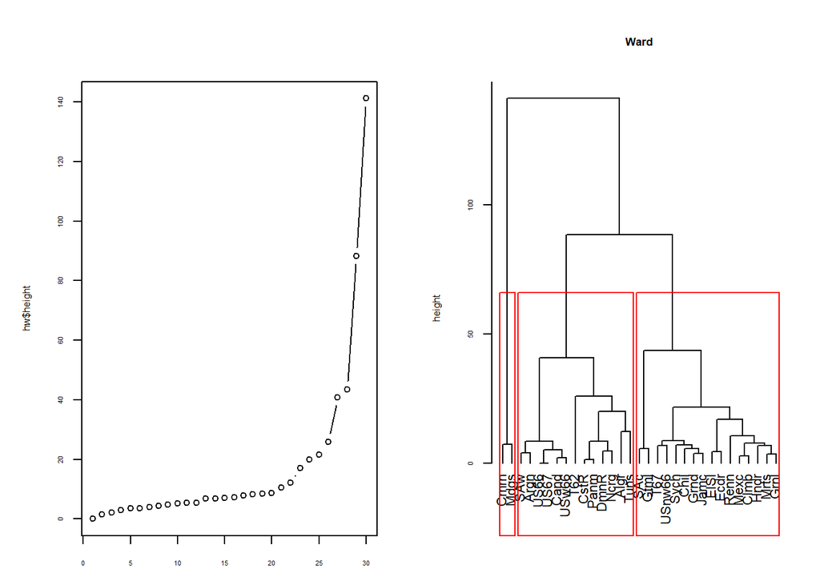

```r
par(mfrow=c(1,2), cex.axis=.5, cex.lab=.7, cex=.7, cex.main=.8, mar=c(3,5,5,2))
plot(hw$height, type="b") # 2, 3 o 5
k <- 3; # tamb´e k=5 (no importa)
plot(hw, labels = rownames(life), ylab = "height", main="Ward", hang=-1)
rect.hclust(hw, k , border = "red")
```

#6. Considera la soluci´o de Ward.D amb k = 3 i fes el proc´es de validaci´o a-posteriori basat en els passos seg¨uents: (a) Aplica cutree() per tenir el cl´uster de cada cas, guarda-ho en clus que sigui un factor, i afegeix la variable al dataframe life. Visualtiza la cap¸calera del fitxer.

```r
k <- 3
clus <- cutree(hw, k)
clus <- as.factor(clus)
life.ampl <- data.frame(life,clus)
head(life.ampl,3)
```

```
##      m0 m25 m50 m75 w0 w25 w50 w75 clus
## Algr 63  51  30  13 67  54  34  15    1
## Cmrn 34  29  13   5 38  32  17   6    2
## Mdgs 38  30  17   7 38  34  20   7    2
```

2. Per a les 8 variables inicials, fes una taula que mostri les seves mitjanes en funci´o del cl´uster. Una possibilitat ´es usar la funci´o by() :

```r
mitj <- by(life.ampl[,1:8], life.ampl$clus, function(x) round(apply(x,2,mean),1),simplify=T)
dfmitj<- as.data.frame(matrix(unlist(mitj),byrow=F,ncol=k)) # k = num clusters
rownames(dfmitj) <- names(mitj[[1]])
colnames(dfmitj) <- paste("clus",1:k,sep="")
dfmitj
```

```
##     clus1 clus2 clus3
## m0   64.8  36.0  58.3
## m25  48.2  29.5  42.6
## m50  24.8  15.0  22.4
## m75   9.4   6.0   7.9
## w0   69.8  38.0  62.9
## w25  51.1  33.0  46.4
## w50  28.7  18.5  25.3
## w75  11.2   6.5   9.7
```

Interpreta els cl´usters en funci´o dels resultats de la taula o, equivalentment, de la representaci´o gr`afica de l’apartat seg¨uent.

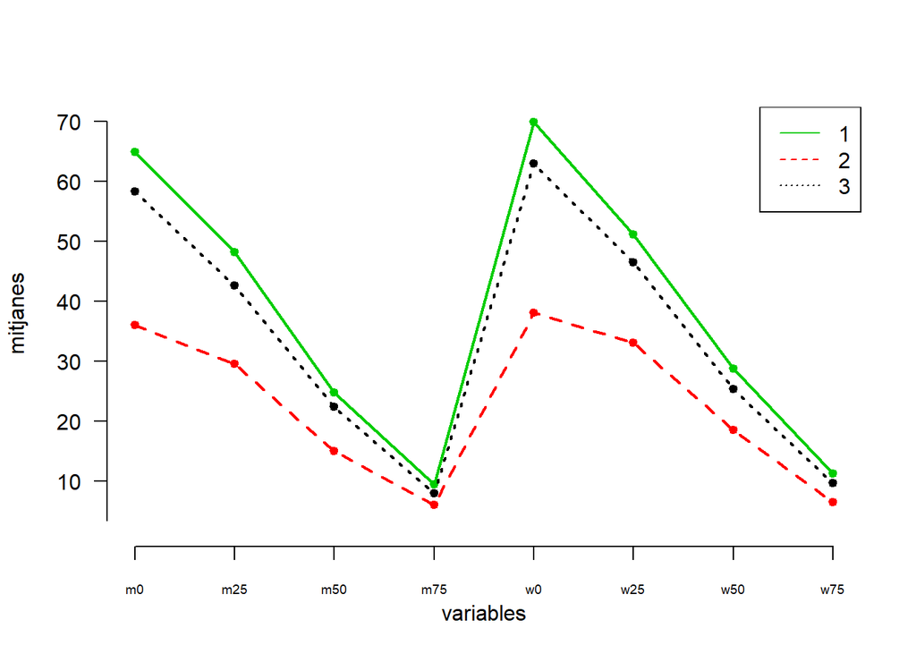

```r
k <- 3
etiq<-rownames(dfmitj)
colors <- c("green3","red","black")
matplot(1:8,dfmitj,type="o",pch=19,lty=1:k,lwd=2,col=colors,axes=F,xlab="variables",ylab="mitjanes",cex=.7)
axis(2,seq(0,70,by=10),las=1)
axis(1,1:8,labels=etiq,line=1,cex.axis=.6)
legend("topright",legend=1:k,lty=1:k,col=colors)
```

Caracteritza de manera univariant els cl´usters en funci´o d’aquests resultats. Quines variables semblen discriminar m´es entre els cl´usters, segons les mitjanes univariants?

4. Fes una matriu de gr`afiques 2D de les relacions bivariades entre les variables referides a l’esperan¸ca de vida masculina de l’arxiu life amb el factor clus, usant pairs() (o si ho preferiu, scatterplotMatrix()). Interpreta els cl´usters en funci´o d’aquesta visualitzaci´o bivariant: Quines parelles de variables discriminen m´es entre cl´usters?

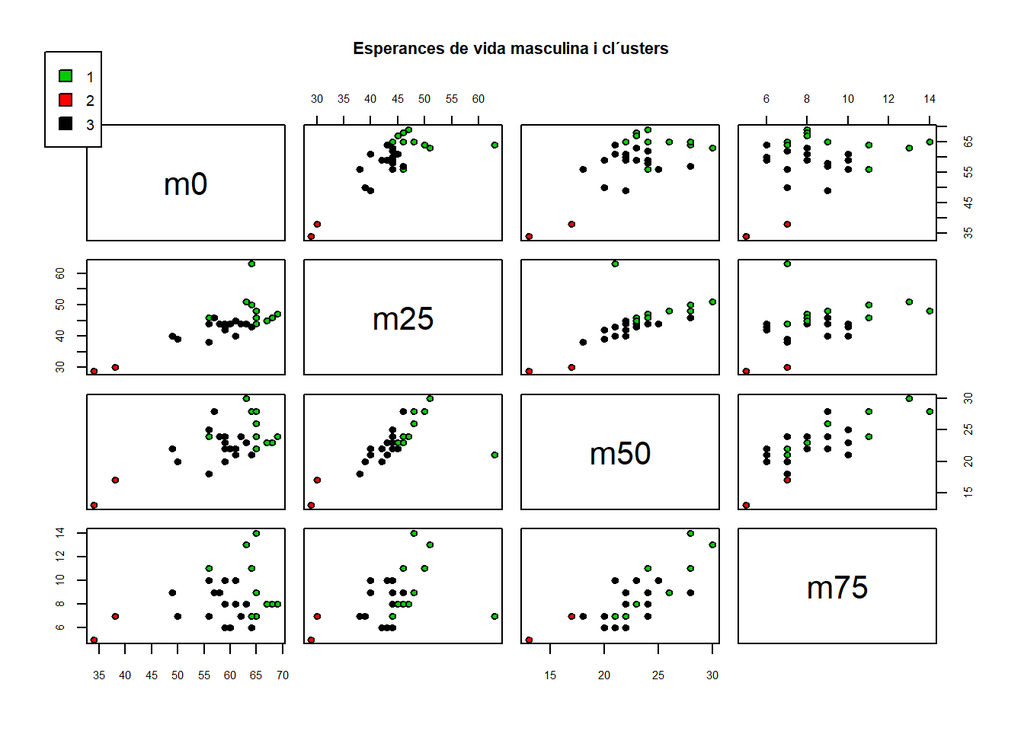

```r
pairs(life.ampl[1:4], main = "Esperances de vida masculina i cl´usters", pch = 21,
bg = colors[unclass(life.ampl$clus)], cex=.9, cex.lab=.7, cex.axis=.7,cex.main=.7)
par(xpd=TRUE)
legend(0,1, as.vector(unique(life.ampl$clus)),fill=colors,cex=.6)
```

5. Aplica PCA (amb 2 components,i sense tipificar (scale.unit=F) a les 8 variables d’esperan¸ca de vida i representa els casos segons l’etiqueta del cl´uster al qual pertanyen. Interpreta els resultats, utilitzant tota la informaci´o del resultat de components principals que faci falta. (En aquest cas, la caracteritzaci´o ´es multivariant.) Nota: En aquest cas, no es tipifica per dues raons, els resultats dels cl´usters s’han fet sense tipificar i les variables tenen totes les mateixes unitats.

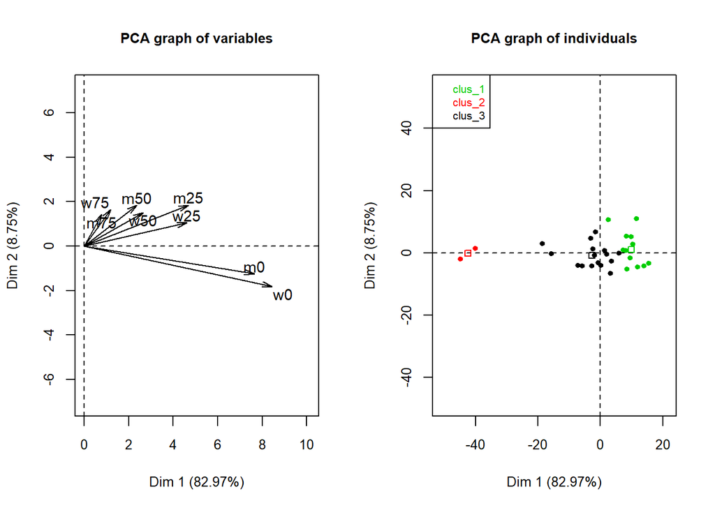

```r
life.pca <- PCA(life.ampl,scale.unit=F,quali.sup=9,ncp=2,graph=F)
par(mfrow=c(1,2),cex=.9, cex.lab=.9, cex.axis=.9,cex.main=.9)
plot(life.pca,choix="var",graph.type = "classic") # Interpreta-ho !!
plot(life.pca,choix="ind",habillage=9,col.hab=colors, label="none",graph.type = "classic")
```

```r
life.pca$eig
```

```
##         eigenvalue percentage of variance cumulative percentage of variance
## comp 1 187.6860798            82.96976957                          82.96977
## comp 2  19.7902049             8.74859096                          91.71836
## comp 3  12.4276060             5.49383103                          97.21219
## comp 4   4.0638351             1.79648623                          99.00868
## comp 5   1.0935440             0.48341942                          99.49210
## comp 6   0.5729244             0.25327083                          99.74537
## comp 7   0.3627259             0.16034904                          99.90572
## comp 8   0.2132776             0.09428292                         100.00000
```

```r
t(apply(life.pca$var$cos2,1,cumsum)) # Interpreta-ho !!
```

```
##         Dim.1     Dim.2
## m0  0.9617482 0.9874121
## m25 0.6536569 0.7548860
## m50 0.4961214 0.7989436
## m75 0.1556171 0.6654331
## w0  0.9476965 0.9917151
## w25 0.8859550 0.9314399
## w50 0.6476045 0.8588727
## w75 0.2192955 0.6394145
```

```r
t(apply(life.pca$ind$cos2,1,cumsum)) # Interpreta-ho !!
```

```
##               Dim.1     Dim.2
## Algr   0.5073896256 0.9759837
## Cmrn   0.9956864149 0.9974800
## Mdgs   0.9957828643 0.9972507
## Mrts   0.2780132338 0.9120161
## Renn   0.5997131476 0.7832267
## Sych   0.6131609889 0.6133347
## SAc    0.9896453347 0.9899976
## SAw    0.7020766971 0.9689022
## Tuns   0.0318883933 0.6221373
## Cand   0.9420936202 0.9876056
## CstR   0.8979835691 0.9061384
## DmnR   0.6382394661 0.9104240
## ElSl   0.2828578574 0.9214875
## Grnl   0.0407499192 0.6141996
## Grnd   0.5716251911 0.5867277
## Gtml   0.9546427804 0.9800377
## Hndr   0.5054696912 0.7602585
## Jamc   0.6048048610 0.9378600
## Mexc   0.3130798541 0.3503266
## Ncrg   0.6724133408 0.8634918
## Panm   0.8166267969 0.8308237
## T62    0.2674978863 0.2875350
## T67    0.1804644276 0.9579466
## US66   0.8560878213 0.9759267
## USnw66 0.0007103963 0.4249537
## USw66  0.8973179528 0.9769928
## US67   0.8560878213 0.9759267
## Argn   0.9564572148 0.9810199
## Chil   0.1209095550 0.1661521
## Clmb   0.5795845354 0.7413705
## Ecdr   0.0422156545 0.8089056
```

```r
#life.comp.clus <- data.frame(life, ind.coord, clus = clus)
#plot(life.comp.clus$Dim.1, life.comp.clus$Dim.2, type = "n")
#text(life.comp.clus$Dim.1, life.comp.clus$Dim.2, labels = clus )
```

7. Una altra opci´o ´es usar la funci´o HCPC() de la llibreria FactoMineR, aplicada directament sobre el resultat de comps principals. Explora: arguments de la funci´o, gr`afiques, resultats, etc. Explora tamb´e la funci´o fviz_cluster() de la llibreria factoextra. Interpreta tots els resultats.

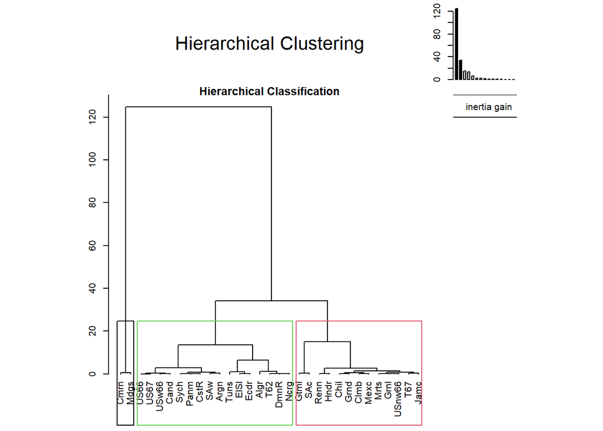

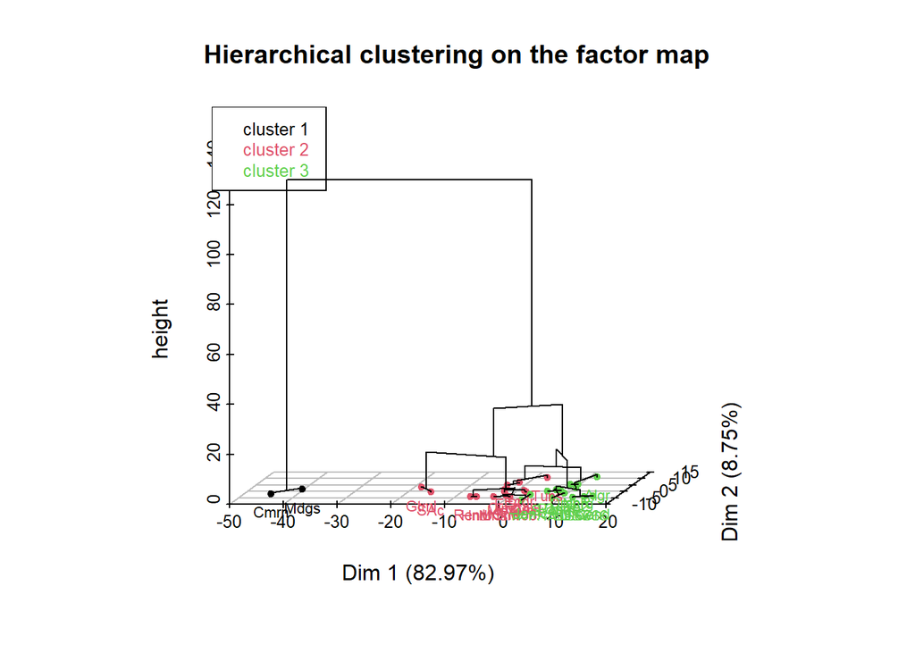

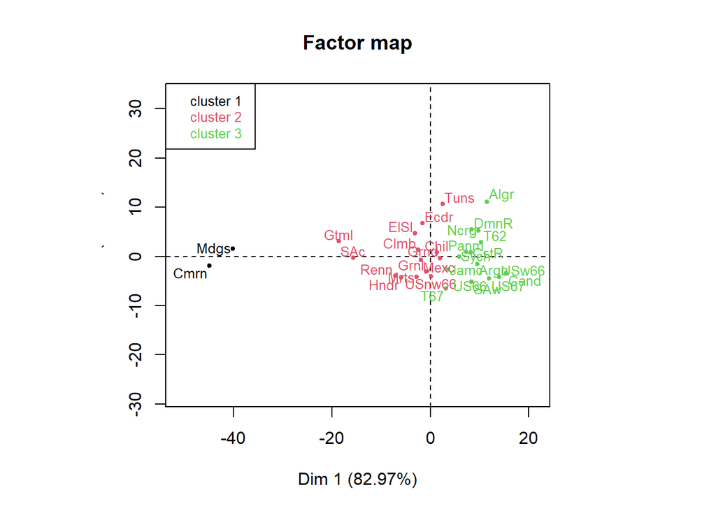

```r
# PCA sense la qualitativa suplement`aria, perqu`e HCPC ja crea la variable cl´uster
library(fBasics)
library(FactoMineR)
life.pca <- PCA(life,scale.unit=F,ncp=2,graph=F) # usem el fitxer original, no l'ampliat

res <- HCPC(life.pca,nb.clust =-1)
```

```r
names(res)
```

```
## [1] "data.clust" "desc.var"   "desc.axes"  "desc.ind"   "call"
```

```r
head(res$data.clust)
```

```
##      m0 m25 m50 m75 w0 w25 w50 w75 clust
## Algr 63  51  30  13 67  54  34  15     3
## Cmrn 34  29  13   5 38  32  17   6     1
## Mdgs 38  30  17   7 38  34  20   7     1
## Mrts 59  42  20   6 64  46  25   8     2
## Renn 56  38  18   7 62  46  25  10     2
## Sych 62  44  24   7 69  50  28  14     3
```

```r
clusHCPC <- res$data.clust$clust
res$data.clust$quanti
```

```r
res$desc.var
```

```
##
## Link between the cluster variable and the quantitative variables
## ================================================================
##          Eta2      P-value
## m0  0.8752773 2.204124e-13
## w0  0.8341254 1.193766e-11
## w25 0.7415166 5.943702e-09
## m25 0.5988005 2.799275e-06
## w50 0.4883461 8.426914e-05
## m50 0.4621569 1.695034e-04
##
## Description of each cluster by quantitative variables
## =====================================================
## $`1`
##        v.test Mean in category Overall mean sd in category Overall sd
## w75 -2.057759              6.5     10.12903            0.5   2.536723
## m50 -3.407390             15.0     22.93548            2.0   3.349872
## w50 -3.411836             18.5     26.29032            1.5   3.284308
## m25 -3.623384             29.5     44.12903            0.5   5.807348
## w25 -4.257102             33.0     47.51613            1.0   4.904711
## w0  -4.341336             38.0     64.19355            0.0   8.678559
## m0  -4.359850             36.0     59.61290            2.0   7.790306
##          p.value
## w75 3.961332e-02
## m50 6.558743e-04
## w50 6.452690e-04
## m25 2.907733e-04
## w25 2.070943e-05
## w0  1.416192e-05
## m0  1.301519e-05
##
## $`2`
## NULL
##
## $`3`
##       v.test Mean in category Overall mean sd in category Overall sd
## m0  3.712685         65.06667     59.61290       1.878534   7.790306
## w0  3.507473         69.93333     64.19355       3.129785   8.678559
## m25 3.047946         47.46667     44.12903       4.716873   5.807348
## w25 3.046149         50.33333     47.51613       1.920648   4.904711
## w50 2.545384         27.86667     26.29032       2.186829   3.284308
## m50 2.318527         24.40000     22.93548       2.576820   3.349872
##          p.value
## m0  0.0002050724
## w0  0.0004523849
## m25 0.0023041165
## w25 0.0023179278
## w50 0.0109157498
## m50 0.0204206912
```

```r
res$desc.ind
```

```
## $para
## Cluster: 1
##     Cmrn     Mdgs
## 2.921532 2.921532
## ------------------------------------------------------------
## Cluster: 2
##     Clmb     Mexc     ElSl     Grnl     Mrts
## 1.614005 2.265102 4.290138 4.683067 4.784593
## ------------------------------------------------------------
## Cluster: 3
##     Argn     CstR     Panm      T62     Sych
## 1.154635 1.609876 2.452721 3.396287 3.445954
##
## $dist
## Cluster: 1
##     Cmrn     Mdgs
## 41.09993 36.33115
## ------------------------------------------------------------
## Cluster: 2
##      SAc     Gtml     Renn     Hndr     ElSl
## 25.00415 24.15223 16.83839 15.72151 13.41167
## ------------------------------------------------------------
## Cluster: 3
##     Cand     Algr    USw66     US66     US67
## 19.65841 18.73791 18.45921 16.57253 16.57253
```

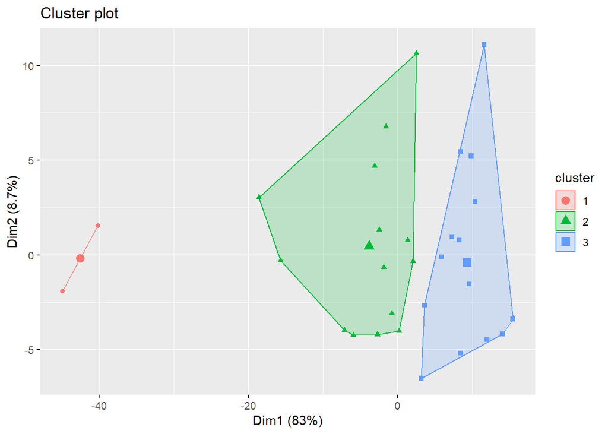

```r
#
require(factoextra)
fviz_cluster(res, geom = "point")
```

```r
table(clus,clusHCPC)
```

```
##     clusHCPC
## clus  1  2  3
##    1  0  1 12
##    2  2  0  0
##    3  0 13  3
```

Per comparar millor, podem recodificar

```r
aux <- clus
aux[clus==1] <- 3
aux[clus==2] <- 1
aux[clus==3] <- 2
table(aux,clusHCPC)
```

```
##    clusHCPC
## aux  1  2  3
##   1  2  0  0
##   2  0 13  3
##   3  0  1 12
```